# 1) Parent class for data downloading

```python
class trading_strategy:

    def __init__(self, coin_name):
        import pandas as pd
        self.name = coin_name
        self.data = pd.DataFrame()

    def get_crypto_data(self):
        import pandas as pd
        import matplotlib.dates as mdates
        import quandl

        data_df = quandl.get(self.name, returns="pandas")

        data_df = data_df.ix[1:,]
        #data_df = data_df.set_index('Date')
        self.data = data_df
        data_df['Date'] = pd.to_datetime(data_df.index)
        self.date = data_df['Date'].apply(mdates.date2num)
        self.open = data_df.Open
        self.high = data_df.High
        self.close = data_df.Close
        self.low = data_df.Low
```

```python
import quandl
quandl.ApiConfig.api_key = "gn1A9WRvXoeB_eT7xQ5H"
```

```python
import warnings
warnings.filterwarnings('ignore')
```

# 2) Trading strategies

## 2.1) Classes

Note: if you are using version 2.2.2 of matplotlib, please change from 'from matplotlib.finance import candlestick_ohlc' to 'from mpl_finance import candlestick_ohlc'.

### 2.1.1) MACD Class

```python
class MACD(trading_strategy):

    def __init__(self, coin_name, sma_f=20, sma_s=50, macd_f=12, macd_s=26, macd_sig=9):
        super().__init__(coin_name)
        self.sma_f = sma_f
        self.sma_s = sma_s
        self.macd_f = macd_f
        self.macd_s = macd_s
        self.macd_sig = macd_sig

    def calculation(self, sma_f=None, sma_s=None, macd_f=None, macd_s=None, macd_sig=None):
        import talib
        import numpy as np

        self.sma_f = np.where(sma_f == None, self.sma_f, sma_f)
        self.sma_s = np.where(sma_s == None, self.sma_s, sma_s)
        self.macd_f = np.where(macd_f == None, self.macd_f, macd_f)
        self.macd_s = np.where(macd_s == None, self.macd_s, macd_s)
        self.macd_sig = np.where(macd_sig == None, self.macd_sig, macd_sig)

        if self.data.empty:
            self.get_crypto_data()

        self.sma_fast = talib.SMA(np.asarray(self.close), self.sma_f)
        self.sma_slow = talib.SMA(np.asarray(self.close), self.sma_s)
        self.macd, self.macdsignal, self.macdhist = talib.MACD(np.asarray(self.close), fastperiod=self.macd_f, slowperiod=self.macd_s, signalperiod=self.macd_sig)

    def plot(self):

        import pandas as pd
        import numpy as np
        import matplotlib.pyplot as plt
        #from matplotlib.finance import candlestick_ohlc
        from mpl_finance import candlestick_ohlc
        import matplotlib.dates as mdates
        import matplotlib.patches as mpatches
        from matplotlib import style

        if self.data.empty:
            self.get_crypto_data()

        self.calculation()
        self.strategy_result()

        ochl = np.array(pd.DataFrame(data = {'0': self.date,'1':self.open,'2':self.high,'3':self.low,'4':self.close}))
        df = self.data

        style.use('ggplot')
        fig = plt.figure(figsize=(10, 10))
        fig.suptitle('Trading Strategy', fontsize=18, fontweight='bold')

        ax1 = plt.subplot2grid((10, 10), (0, 0), rowspan=6, colspan=10)
        cstick = candlestick_ohlc(ax1, ochl, width=.6, colorup='#53c156', colordown='#ff1717')
        ax1.plot(df['sma_fast'], c='blue',label = "SMA {0}".format(self.sma_f))
        ax1.plot(df['sma_slow'], c='yellow', label = "SMA {0}".format(self.sma_s))
        ax1.annotate('%0.2f' % df.ix[-1, 'close'], xy=(1, df.ix[-1, 'close']), xytext=(8, 0), xycoords=('axes fraction', 'data'), textcoords='offset points')

        buys = self.result['result'][self.result['result'] == 1]
        sells = self.result['result'][self.result['result'] == -1]
        ax1.plot(buys.index, self.result['close'].ix[buys.index],'^', markersize=6, color='m', label ='Buy')
        ax1.plot(sells.index, self.result['close'].ix[sells.index],'v', markersize=6, color='k', label ='Sell')

        ax1.xaxis.set_visible(False)
        ax1.set_title('Strategy: MACD for {0} \n P&L: ${1:,.3f} '.format(self.name,self.PL()))
        ax1.set_ylabel('{0}'.format(self.name))
        ax1.legend()

        ax2 = plt.subplot2grid((10, 10), (6, 0), rowspan=3, colspan=10, sharex=ax1)
        ax2.plot(df['macdsignal'], label = "macdsignal {0}".format(self.macd_sig))
        ax2.plot(df['macd'], label = "macd {0}:{1}".format(self.macd_f, self.macd_s))
        ax2.plot(df['macdhist'])
        ax2.fill_between(df.index, df['macdhist'], facecolor='#9999ff')
        ax2.xaxis_date()
        ax2.xaxis.set_major_formatter(mdates.DateFormatter('%y-%m-%d %H:%M:%S'))
        ax2.set_ylabel('MACD')
        ax2.legend()

        plt.xticks(rotation=45)
        plt.xlabel('Date Hours:Minutes')
        return(plt)

    def strategy_result(self):
        import pandas as pd

        self.calculation()
        df = pd.DataFrame(index = self.data.index)
        df['open'], df['close'], df['high'], df['low'] = self.open, self.close, self.high, self.low
        df['sma_fast'], df['sma_slow'], df['macd'], df['macdsignal'], df['macdhist'] = self.sma_fast, self.sma_slow, self.macd, self.macdsignal, self.macdhist
        self.data = df

        result = self.data[['close','sma_fast', 'sma_slow', 'macd', 'macdsignal', 'macdhist']].dropna()

        macdhist = result['macdhist']
        ma_f = result['sma_fast']
        ma_s = result['sma_slow']

        li = [0]*len(macdhist)
        li[0] = 0
        curr1 = 0
        curr2 = 0
        for i in range(1, len(macdhist)):

            if curr1 == 1 and macdhist[i] > 0:
                li[i] = 0
            elif curr1 == -1 and macdhist[i] < 0:
                li[i] = 0
            elif macdhist[i-1] < 0 and macdhist[i] > 0:
                li[i] = 1
                curr1 = 1
            elif macdhist[i-1] > 0 and macdhist[i] < 0:
                li[i] = -1
                curr1 = -1

            if curr2 == 1 and ma_f[i-1] > ma_s[i-1]:
                li[i-1] = li[i-1]
            elif curr2 == -1 and ma_f[i-1] < ma_s[i-1]:
                li[i-1] = li[i-1]
            elif ma_f[i-1] > ma_s[i-1]:
                if li[i-1] == 0:
                    li[i-1] = 1
                curr2 = 1
            elif ma_f[i-1] < ma_s[i-1]:
                if li[i-1] == 0:
                    li[i-1] = -1
                curr2 = -1

            if li[len(macdhist)-1] == 0 and curr1 == 1:
                li[len(macdhist)-1] = -1
            elif li[len(macdhist)-1] == 0 and curr1 == -1:
                li[len(macdhist)-1] = 1

        result['result'] = li
        self.result = result
        return(result)

    def PL(self):

        self.strategy_result()
        result = self.result

        df = result[result['result'] != 0]
        df = df[['close', 'result']]
        PL = [0]*(len(df)+1)

        quantity = [0]*len(df)

        for i in range(0, len(df)):
            if df.ix[i,'result'] == -1 and sum(quantity) > 0:
                PL[i] = df.ix[i,'close']*sum(quantity)
                quantity[i] = sum(quantity)*(-1)
            elif df.ix[i,'result'] == 1:
                PL[i] = df.ix[i,'close']*(-1)
                quantity[i] = 1
            elif sum(PL) <= 0 and sum(quantity) == 0:
                PL[i] = 0
                quantity[i] = 0

        if sum(quantity) > 0:
            PL[len(df)] = df.ix[len(df)-1,'close']*sum(quantity)

        return(sum(PL))
```

### 2.1.2) RSI Class

```python
class RSI(trading_strategy):

    def __init__(self, coin_name, buy_all = True, rsi_up = 70, rsi_low = 30, rsi_period = 14):
        super().__init__(coin_name)
        self.buy_all = True
        self.rsi_up = rsi_up
        self.rsi_low = rsi_low
        self.rsi_period = rsi_period

    def calculation(self, rsi_up=None, rsi_low=None, rsi_period=None):

        import talib
        import numpy as np

        self.rsi_up = np.where(rsi_up == None, self.rsi_up, rsi_up)
        self.rsi_low = np.where(rsi_low == None, self.rsi_low, rsi_low)
        self.rsi_period = np.where(rsi_period == None, self.rsi_period, rsi_period)

        if self.data.empty:
            self.get_crypto_data()

        self.rsi = talib.RSI(np.asarray(self.close), timeperiod=self.rsi_period)

    def plot(self):

        import pandas as pd
        import numpy as np
        import matplotlib.pyplot as plt
        #from matplotlib.finance import candlestick_ohlc
        from mpl_finance import candlestick_ohlc
        import matplotlib.dates as mdates
        import matplotlib.patches as mpatches
        from matplotlib import style

        if self.data.empty:
            self.get_crypto_data()

        self.calculation()
        self.strategy_result()
        ochl = np.array(pd.DataFrame(data = {'0': self.date,'1':self.open,'2':self.high,'3':self.low,'4':self.close}))
        df = self.data

        style.use('ggplot')
        fig = plt.figure(figsize=(10, 10))
        fig.suptitle('Trading Strategy', fontsize=18, fontweight='bold')

        ax1 = plt.subplot2grid((10, 10), (0, 0), rowspan=6, colspan=10)
        cstick = candlestick_ohlc(ax1, ochl, width=.6, colorup='#53c156', colordown='#ff1717')
        ax1.annotate('%0.2f' % df.ix[-1, 'close'], xy=(1, df.ix[-1, 'close']), xytext=(8, 0), xycoords=('axes fraction', 'data'), textcoords='offset points')

        buys = self.result['result'][self.result['result'] == 1]
        sells = self.result['result'][self.result['result'] == -1]
        ax1.plot(buys.index, self.result['close'].ix[buys.index],'^', markersize=6, color='m', label ='Buy')
        ax1.plot(sells.index, self.result['close'].ix[sells.index],'v', markersize=6, color='k', label ='Sell')

        ax1.xaxis.set_visible(False)
        ax1.set_title('Strategy: RSI for {0} \n P&L: ${1:,.3f} '.format(self.name,self.PL()))
        ax1.set_ylabel('{0}'.format(self.name))
        ax1.legend()

        ax2 = plt.subplot2grid((10, 10), (6, 0), rowspan=3, colspan=10, sharex=ax1)
        ax2.plot(df['rsi'], label = "RSI {0}".format(self.rsi_period))
        ax2.axhline(y = self.rsi_up, color='green', linestyle='-')
        ax2.annotate('%0.2f' % self.rsi_up, xy=(1, self.rsi_up), xytext=(8, 0), xycoords=('axes fraction', 'data'), textcoords='offset points')
        ax2.axhline(y = self.rsi_low, color='blue', linestyle='-')
        ax2.annotate('%0.2f' % self.rsi_low, xy=(1, 40), xytext=(8, 0), xycoords=('axes fraction', 'data'), textcoords='offset points')
        ax2.xaxis_date()
        ax2.xaxis.set_major_formatter(mdates.DateFormatter('%y-%m-%d %H:%M:%S'))
        ax2.set_ylabel('RSI')
        ax2.legend()

        plt.xticks(rotation=45)
        plt.xlabel('Date Hours:Minutes')
        return(plt)

    def strategy_result(self):

        import pandas as pd

        self.calculation()
        df = pd.DataFrame(index = self.data.index)
        df['open'], df['close'], df['high'], df['low'] = self.open, self.close, self.high, self.low
        df['rsi'] = self.rsi
        self.data = df

        result = self.data[['close','rsi']].dropna()

        rsi = result['rsi']
        li = [0]*len(rsi)
        for i in range(1, len(rsi)):
            if rsi[i] >= self.rsi_up:
                li[i] = -1
            elif rsi[i] <= self.rsi_low:
                li[i] = 1
            else:
                li[i] = 0

        result['result'] = li
        self.result = result
        return(result)

    def PL(self):

        self.strategy_result()
        result = self.result

        df = result[['close', 'result']]
        PL = [0]*(len(df)+1)

        quantity = [0]*len(df)

        if df.ix[0,'result'] == 1:
            PL[0] = df.ix[0,'close']*(-1)
            quantity[0] = 1

        for i in range(1, len(df)-1):
            if self.buy_all == True:
                if df.ix[i,'result'] == -1 and sum(quantity) > 0 and df.ix[i-1,'result'] == 0:
                    PL[i] = df.ix[i,'close']*sum(quantity)
                    quantity[i] = sum(quantity)*(-1)
                elif df.ix[i,'result'] == 1 :
                    PL[i] = df.ix[i,'close']*(-1)
                    quantity[i] = 1
                elif sum(PL) <= 0 and sum(quantity) == 0:
                    PL[i] = 0
                    quantity[i] = 0
            else:
                if df.ix[i,'result'] == -1 and sum(quantity) > 0 and df.ix[i-1,'result'] == 0:
                    PL[i] = df.ix[i,'close']*sum(quantity)
                    quantity[i] = sum(quantity)*(-1)
                elif df.ix[i,'result'] == 1 and df.ix[i+1,'result'] == 0:
                    PL[i] = df.ix[i,'close']*(-1)
                    quantity[i] = 1
                elif sum(PL) <= 0 and sum(quantity) == 0:
                    PL[i] = 0
                    quantity[i] = 0

        if sum(quantity) > 0:
            PL[len(df)] = df.ix[len(df)-1,'close']*sum(quantity)

        return(sum(PL))
```

### 2.1.3) MACD and RSI Class

```python
class MACD_RSI(trading_strategy):

    def __init__(self, coin_name, rsi_up = 70, rsi_low = 30, rsi_period = 14,sma_f=20, sma_s=50, macd_f=12, macd_s=26, macd_sig=9):
        super().__init__(coin_name)
        self.rsi_up = rsi_up
        self.rsi_low = rsi_low
        self.rsi_period = rsi_period
        self.sma_f = sma_f
        self.sma_s = sma_s
        self.macd_f = macd_f
        self.macd_s = macd_s
        self.macd_sig = macd_sig

    def calculation(self, rsi_up=None, rsi_low=None, rsi_period=None, sma_f=None, sma_s=None, macd_f=None, macd_s=None, macd_sig=None):

        import talib
        import numpy as np

        self.sma_f = np.where(sma_f == None, self.sma_f, sma_f)
        self.sma_s = np.where(sma_s == None, self.sma_s, sma_s)
        self.macd_f = np.where(macd_f == None, self.macd_f, macd_f)
        self.macd_s = np.where(macd_s == None, self.macd_s, macd_s)
        self.macd_sig = np.where(macd_sig == None, self.macd_sig, macd_sig)
        self.rsi_up = np.where(rsi_up == None, self.rsi_up, rsi_up)
        self.rsi_low = np.where(rsi_low == None, self.rsi_low, rsi_low)
        self.rsi_period = np.where(rsi_period == None, self.rsi_period, rsi_period)

        if self.data.empty:
            self.get_crypto_data()

        self.sma_fast = talib.SMA(np.asarray(self.close), self.sma_f)
        self.sma_slow = talib.SMA(np.asarray(self.close), self.sma_s)
        self.macd, self.macdsignal, self.macdhist = talib.MACD(np.asarray(self.close), fastperiod=self.macd_f, slowperiod=self.macd_s, signalperiod=self.macd_sig)
        self.rsi = talib.RSI(np.asarray(self.close), timeperiod=self.rsi_period)

    def plot(self):

        import pandas as pd
        import numpy as np
        import matplotlib.pyplot as plt
        #from matplotlib.finance import candlestick_ohlc
        from mpl_finance import candlestick_ohlc
        import matplotlib.dates as mdates
        import matplotlib.patches as mpatches
        from matplotlib import style

        if self.data.empty:
            self.get_crypto_data()

        self.calculation()
        self.strategy_result()

        ochl = np.array(pd.DataFrame(data = {'0': self.date,'1':self.open,'2':self.high,'3':self.low,'4':self.close}))
        df = pd.DataFrame(index = self.data.index)
        df = self.data

        style.use('ggplot')
        fig = plt.figure(figsize=(10, 10))
        fig.suptitle('Trading Strategy', fontsize=14, fontweight='bold')

        ax1 = plt.subplot2grid((10, 10), (0, 0), rowspan=6, colspan=10)
        cstick = candlestick_ohlc(ax1, ochl, width=.6, colorup='#53c156', colordown='#ff1717')
        ax1.plot(df['sma_fast'], c='blue',label = "SMA {0}".format(self.sma_f))
        ax1.plot(df['sma_slow'], c='yellow',label = "SMA {0}".format(self.sma_s))
        ax1.annotate('%0.2f' % df.ix[-1, 'close'], xy=(1, df.ix[-1, 'close']), xytext=(8, 0), xycoords=('axes fraction', 'data'), textcoords='offset points')

        buys = self.result['result'][self.result['result'] == 1]
        sells = self.result['result'][self.result['result'] == -1]
        ax1.plot(buys.index, self.result['close'].ix[buys.index],'^', markersize=6, color='m', label ='Buy')
        ax1.plot(sells.index, self.result['close'].ix[sells.index],'v', markersize=6, color='k', label ='Sell')

        ax1.xaxis.set_visible(False)
        ax1.set_title('Strategy: MACD and RSI for {0} \n P&L: ${1:,.3f} '.format(self.name,self.PL()))
        ax1.set_ylabel('{0}'.format(self.name))
        ax1.legend()

        ax2 = plt.subplot2grid((10, 10), (6, 0), rowspan=2, colspan=10, sharex=ax1)
        ax2.plot(df['macdsignal'], label = "macdsignal {0}".format(self.macd_sig))
        ax2.plot(df['macd'], label = "macd {0}:{1}".format(self.macd_f, self.macd_s))
        ax2.plot(df['macdhist'])
        ax2.fill_between(df.index, df['macdhist'], facecolor='#9999ff')
        ax2.set_ylabel('MACD')
        ax2.xaxis.set_visible(False)
        ax2.legend()

        ax3 = plt.subplot2grid((10, 10), (8, 0), rowspan=2, colspan=10, sharex=ax1)
        ax3.plot(df['rsi'], label = "RSI {0}".format(self.rsi_period))
        ax3.axhline(y = self.rsi_up, color='green', linestyle='-')
        ax3.annotate('%0.2f' % self.rsi_up, xy=(1, self.rsi_up), xytext=(8, 0), xycoords=('axes fraction', 'data'), textcoords='offset points')
        ax3.axhline(y = self.rsi_low, color='blue', linestyle='-')
        ax3.annotate('%0.2f' % self.rsi_low, xy=(1, 40), xytext=(8, 0), xycoords=('axes fraction', 'data'), textcoords='offset points')
        ax3.xaxis_date()
        ax3.xaxis.set_major_formatter(mdates.DateFormatter('%y-%m-%d %H:%M:%S'))
        ax3.set_ylabel('RSI')
        ax3.legend()


        plt.xticks(rotation=45)
        plt.xlabel('Date Hours:Minutes')
        return(plt)

    def macd_result(self):

        macdhist = self.result['macdhist']
        ma_f = self.result['sma_fast']
        ma_s = self.result['sma_slow']

        li = [0]*len(macdhist)
        li[0] = 0
        curr1 = 0
        curr2 = 0
        for i in range(1, len(macdhist)):

            if curr1 == 1 and macdhist[i] > 0:
                li[i] = 0
            elif curr1 == -1 and macdhist[i] < 0:
                li[i] = 0
            elif macdhist[i-1] < 0 and macdhist[i] > 0:
                li[i] = 1
                curr1 = 1
            elif macdhist[i-1] > 0 and macdhist[i] < 0:
                li[i] = -1
                curr1 = -1

            if curr2 == 1 and ma_f[i-1] > ma_s[i-1]:
                li[i-1] = li[i-1]
            elif curr2 == -1 and ma_f[i-1] < ma_s[i-1]:
                li[i-1] = li[i-1]
            elif ma_f[i-1] > ma_s[i-1]:
                if li[i-1] == 0:
                    li[i-1] = 1
                curr2 = 1
            elif ma_f[i-1] < ma_s[i-1]:
                if li[i-1] == 0:
                    li[i-1] = -1
                curr2 = -1

            if li[len(macdhist)-1] == 0 and curr1 == 1:
                li[len(macdhist)-1] = -1
            elif li[len(macdhist)-1] == 0 and curr1 == -1:
                li[len(macdhist)-1] = 1
        return(li)

    def rsi_result(self):

        rsi = self.result['rsi']
        li = [0]*len(rsi)
        for i in range(1, len(rsi)):
            if rsi[i] >= self.rsi_up:
                li[i] = -1
            elif rsi[i] <= self.rsi_low:
                li[i] = 1
            else:
                li[i] = 0
        return(li)

    def strategy_result(self):

        import pandas as pd

        self.calculation()
        df = pd.DataFrame(index = self.data.index)

        df['open'], df['close'], df['high'], df['low'] = self.open, self.close, self.high, self.low
        df['sma_fast'], df['sma_slow'], df['macd'], df['macdsignal'], df['macdhist'] = self.sma_fast, self.sma_slow, self.macd, self.macdsignal, self.macdhist
        df['rsi'] = self.rsi
        self.data = df

        result = self.data[['close', 'sma_fast', 'sma_slow', 'macd', 'macdsignal', 'macdhist', 'rsi']].dropna()
        self.result = result
        result['macd_result'] = self.macd_result()
        result['rsi_result'] = self.rsi_result()

        macd_result = result['macd_result']
        rsi_result = result['rsi_result']
        li = [0]*len(macd_result)

        for i in range(1, len(macd_result)):
            if macd_result[i] == 1 and rsi_result[i] == 1:
                li[i] = 1
            elif macd_result[i] == -1 and rsi_result[i] == -1:
                li[i] = -1
            else:
                li[i] = 0

        result['result'] = li
        self.result = result
        return(result)

    def PL(self):

        self.strategy_result()
        result = self.result

        df = result[result['result'] != 0]
        df = df[['close', 'result']]
        PL = [0]*(len(df)+1)

        quantity = [0]*len(df)

        for i in range(0, len(df)):
            if df.ix[i,'result'] == -1 and sum(quantity) > 0:
                PL[i] = df.ix[i,'close']*sum(quantity)
                quantity[i] = sum(quantity)*(-1)
            elif df.ix[i,'result'] == 1:
                PL[i] = df.ix[i,'close']*(-1)
                quantity[i] = 1
            elif sum(PL) <= 0 and sum(quantity) == 0:
                PL[i] = 0
                quantity[i] = 0
            if sum(quantity) > 0:
                PL[len(df)] = df.ix[len(df)-1,'close']*sum(quantity)

        return(sum(PL))
```

## 2.2) Strategy Demo

### 2.2.1) MACD Strategy Demo

Create object for MACD strategy

```python
macd = MACD('BCHARTS/KRAKENUSD')
```

Default of MACD parameters as below:

- Fast SMA : 20
- Slow SMA : 50
- Fast MACD : 12
- Slow MACD : 26
- MACD Signal: 9

```
<module 'matplotlib.pyplot' from 'c:\\users\\nackz\\desktop\\steven~1\\subjects\\fe595-~1\\project\\my_pro~1\\lib\\site-packages\\matplotlib\\pyplot.py'>
```

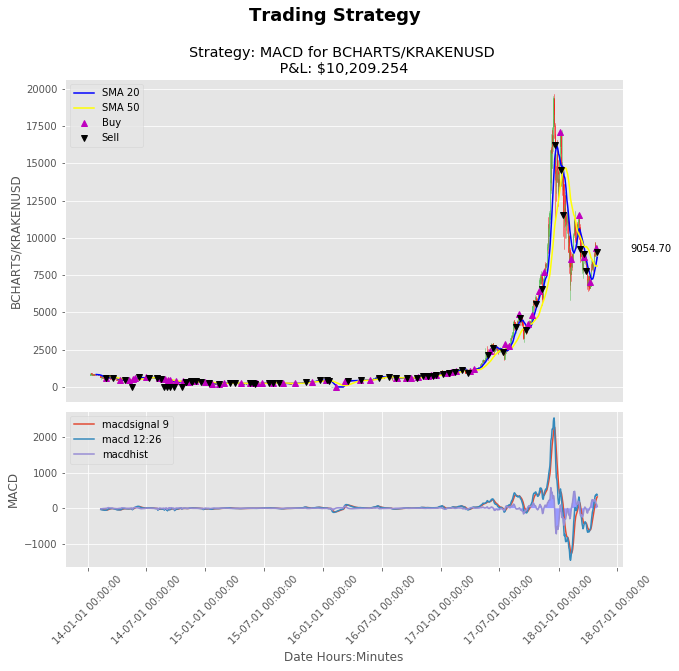

```python
macd.plot()
```

When you want to change any parameter, then use calculation() method to update the value.  
In this demo, we change fast moving average from 20 to 15.

```
<module 'matplotlib.pyplot' from 'c:\\users\\nackz\\desktop\\steven~1\\subjects\\fe595-~1\\project\\my_pro~1\\lib\\site-packages\\matplotlib\\pyplot.py'>
```

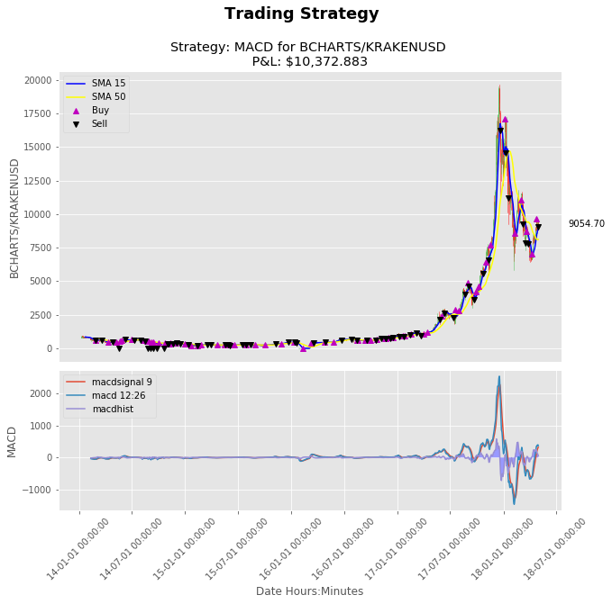

```python
macd.calculation(sma_f=15)
macd.plot()
```

### 2.2.2) RSI Strategy Demo

Create object for RSI strategy

```python
rsi = RSI('BCHARTS/KRAKENUSD')
```

Default of RSI parameters as below:

- Upper bound : 70
- Lower bound : 30
- Period : 14

```
<module 'matplotlib.pyplot' from 'c:\\users\\nackz\\desktop\\steven~1\\subjects\\fe595-~1\\project\\my_pro~1\\lib\\site-packages\\matplotlib\\pyplot.py'>
```

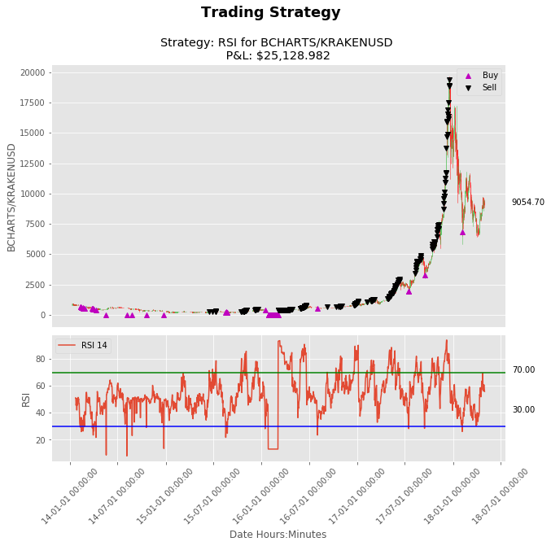

```python
rsi.plot()
```

You can update RSI parameters using calculation() method.

```
<module 'matplotlib.pyplot' from 'c:\\users\\nackz\\desktop\\steven~1\\subjects\\fe595-~1\\project\\my_pro~1\\lib\\site-packages\\matplotlib\\pyplot.py'>
```

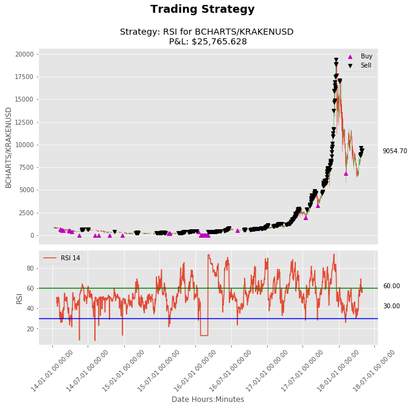

```python
rsi.calculation(rsi_up = 60)
rsi.plot()
```

### 2.2.3) MACD and RSI Strategy Demo

Create object for MACD and RSI strategy

```python
macd_rsi = MACD_RSI('BCHARTS/KRAKENUSD')
```

Default of MACD parameters as below:

- Fast SMA : 20
- Slow SMA : 50
- Fast MACD : 12
- Slow MACD : 26
- MACD Signal: 9
- Upper bound RSI : 70
- Lower bound RSI : 30
- Period RSI : 14

```
<module 'matplotlib.pyplot' from 'c:\\users\\nackz\\desktop\\steven~1\\subjects\\fe595-~1\\project\\my_pro~1\\lib\\site-packages\\matplotlib\\pyplot.py'>
```

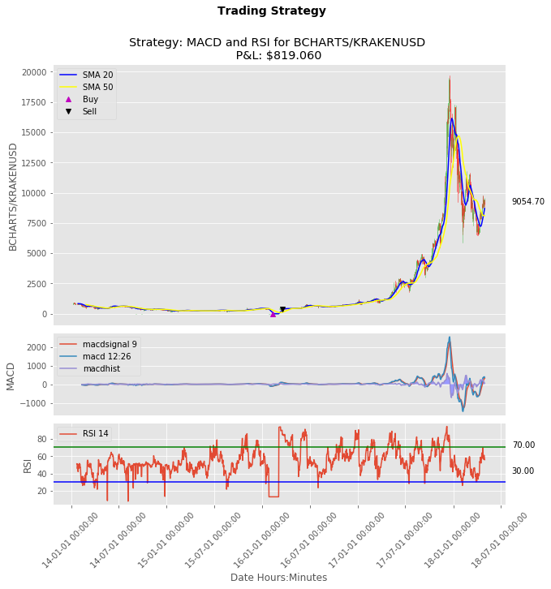

```python
macd_rsi.plot()
```

You can update MACD and RSI parameters using calculation() method.

```
<module 'matplotlib.pyplot' from 'c:\\users\\nackz\\desktop\\steven~1\\subjects\\fe595-~1\\project\\my_pro~1\\lib\\site-packages\\matplotlib\\pyplot.py'>
```

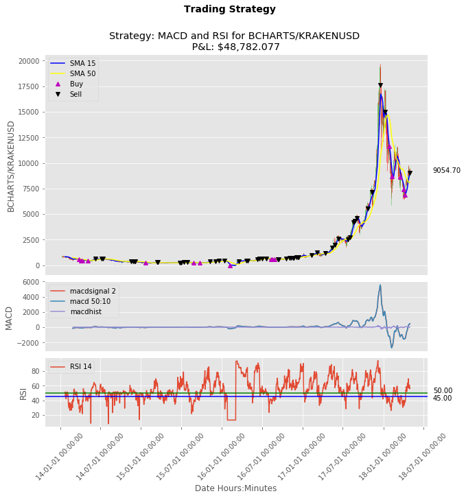

```python
macd_rsi.calculation(sma_f=15,  macd_f=50, macd_s=10, macd_sig=2, sma_s=50,rsi_up=50, rsi_low=45)
macd_rsi.plot()
```

# 3) Machine Learning

## 3.1) Class

```python
class ML:

    def __init__(self, X = [], y = [], strategy_result = None):
        from sklearn.cross_validation import train_test_split
        if  X == [] and y == []:
            self.strategy_result = strategy_result
            self.X = strategy_result.ix[0:(strategy_result.shape[0]),0:(strategy_result.shape[-1]-1)].values
            self.y = strategy_result.ix[0:(strategy_result.shape[0]),-1].values
            self.X_trn, self.X_tst, self.y_trn, self.y_tst = train_test_split(self.X, self.y, test_size=0.30, random_state=42)

        else:
            self.X = X
            self.y = y
            self.X_trn, self.X_tst, self.y_trn, self.y_tst = train_test_split(self.X, self.y, test_size=0.30, random_state=42)

    def compute_lda(self):
        import pandas as pd
        from sklearn.discriminant_analysis import LinearDiscriminantAnalysis as LDA

        lda = LDA(n_components = 2)

        if len(self.y_tst[self.y_tst==1]) > 1 or len(self.y_tst[self.y_tst==-1]) > 1:
            lda.fit(self.X_trn, self.y_trn)
            y_pred = lda.predict(self.X_tst)
            self.model_lda = lda

            df = pd.DataFrame(data = {'test' : self.y_tst, 'predict' : y_pred})
            self.df_lda = df

            from sklearn.metrics import accuracy_score
            self.accuracy_lda = accuracy_score(df['predict'], df['test'])

        elif len(y_tst[y_tst==1]) <= 1 or len(y_tst[y_tst==-1]) <= 1:
            df = pd.DataFrame(data = {'test' : [0], 'predict' : [0]})
            self.df_lda = df
            self.accuracy_lda = 0
        self.model_lda.fit(self.X, self.y)

    def compute_qda(self):
        import pandas as pd
        from sklearn.discriminant_analysis import QuadraticDiscriminantAnalysis as QDA

        qda = QDA()

        if len(self.y_tst[self.y_tst==1]) > 1 or len(self.y_tst[self.y_tst==-1]) > 1:
            qda.fit(self.X_trn, self.y_trn)
            y_pred = qda.predict(self.X_tst)
            self.model_qda = qda

            df = pd.DataFrame(data = {'test' : self.y_tst, 'predict' : y_pred})
            self.df_qda = df

            from sklearn.metrics import accuracy_score
            self.accuracy_qda = accuracy_score(df['predict'], df['test'])

        elif len(self.y_tst[self.y_tst==1]) <= 1 or len(self.y_tst[self.y_tst==-1]) <= 1:
            df = pd.DataFrame(data = {'test' : [0], 'predict' : [0]})
            self.df_qda = df
            self.accuracy_qda = 0
        self.model_qda.fit(self.X, self.y)

    def compute_gnb(self):
        import pandas as pd
        from sklearn.naive_bayes import GaussianNB

        gnb = GaussianNB()

        if len(self.y_tst[self.y_tst==1]) > 1 or len(self.y_tst[self.y_tst==-1]) > 1:
            gnb.fit(self.X_trn, self.y_trn)
            y_pred = gnb.predict(self.X_tst)
            self.model_gnb = gnb

            df = pd.DataFrame(data = {'test' : self.y_tst, 'predict' : y_pred})
            self.df_gnb = df

            from sklearn.metrics import accuracy_score
            self.accuracy_gnb = accuracy_score(df['predict'], df['test'])

        elif len(self.y_tst[self.y_tst==1]) <= 1 or len(self.y_tst[self.y_tst==-1]) <= 1:
            df = pd.DataFrame(data = {'test' : [0], 'predict' : [0]})
            self.df_gnb = df
            self.accuracy_gnb = 0
        self.model_gnb.fit(self.X, self.y)

    def compute_svm(self):
        import pandas as pd
        from sklearn import svm as SVM

        svm = SVM.SVC(kernel='rbf')

        if len(self.y_tst[self.y_tst==1]) > 1 or len(self.y_tst[self.y_tst==-1]) > 1:
            svm.fit(self.X_trn, self.y_trn)
            y_pred = svm.predict(self.X_tst)
            self.model_svm = svm

            df = pd.DataFrame(data = {'test' : self.y_tst, 'predict' : y_pred})
            self.df_svm = df

            from sklearn.metrics import accuracy_score
            self.accuracy_svm = accuracy_score(df['predict'], df['test'])

        elif len(self.y_tst[self.y_tst==1]) <= 1 or len(self.y_tst[self.y_tst==-1]) <= 1:
            df = pd.DataFrame(data = {'test' : [0], 'predict' : [0]})
            self.df_svm = df
            self.accuracy_svm = 0
        self.model_svm.fit(self.X, self.y)

    def compute_rf(self):
        import pandas as pd
        from sklearn.ensemble import RandomForestClassifier

        rf = RandomForestClassifier(n_jobs=2, random_state=0)

        if len(self.y_tst[self.y_tst==1]) > 1 or len(self.y_tst[self.y_tst==-1]) > 1:
            rf.fit(self.X_trn, self.y_trn)
            y_pred =rf.predict(self.X_tst)
            self.model_rf = rf

            df = pd.DataFrame(data = {'test' : self.y_tst, 'predict' : y_pred})
            self.df_rf = df

            from sklearn.metrics import accuracy_score
            self.accuracy_rf = accuracy_score(df['predict'], df['test'])

        elif len(self.y_tst[self.y_tst==1]) <= 1 or len(self.y_tst[self.y_tst==-1]) <= 1:
            df = pd.DataFrame(data = {'test' : [0], 'predict' : [0]})
            self.df_rf = df
            self.accuracy_rf = 0
        self.model_rf.fit(self.X, self.y)

    def result(self):

        self.compute_lda()
        self.compute_qda()
        self.compute_gnb()
        self.compute_svm()
        self.compute_rf()

        self.accuracy = {'LDA' : round(self.accuracy_lda*100,3), 'QDA' : round(self.accuracy_qda*100,3), 'GNB' : round(self.accuracy_gnb*100,3), 'SVM' : round(self.accuracy_svm*100,3), 'RF' : round(self.accuracy_rf*100,3)}

        return(self.accuracy)
```

## 3.2) ML Demo

### 3.2.1) MACD ML Demo

Create object for ML models

```python
import warnings
warnings.filterwarnings('ignore')

ml_macd = ML(strategy_result = macd.result)
ml_rsi = ML(strategy_result = rsi.result)
ml_macd_rsi = ML(strategy_result = macd_rsi.result)
```

Using result() method reports the accurate rate.

```python
ml_macd.result()
```

```
{'GNB': 23.799, 'LDA': 89.956, 'QDA': 27.293, 'RF': 90.611, 'SVM': 90.611}
```

```python
ml_rsi.result()
```

```
{'GNB': 98.507, 'LDA': 97.015, 'QDA': 98.294, 'RF': 99.787, 'SVM': 73.987}
```

```python
ml_macd_rsi.result()
```

```
{'GNB': 99.782, 'LDA': 98.035, 'QDA': 3.712, 'RF': 100.0, 'SVM': 95.633}
```

# 4) Back testing

## 4.1) Class

```python
from zipline.api import order, record, symbol, order_target
from zipline.algorithm import TradingAlgorithm
import matplotlib.pyplot as plt

class backtest():

    def __init__(self, name, mname, data, quantity, start=200):
        self.name = name
        self.mname = mname

        from collections import OrderedDict
        import pandas as pd
        import pytz
        data1 = OrderedDict()

        data1['BTC'] = data
        panel = pd.Panel(data1)
        panel.major_axis.tz_localize(pytz.utc)

        self.data = panel
        self.quantity = quantity
        self.shape = data.shape[-1]-1
        self.start = start


    def initialize(self, context):
        self.context = context
        self.context.i = 0
        self.context.asset = symbol('BTC')


    def handle_data(self, context, data):
        self.context.i += 1
        if self.context.i < self.start:
            order(context.asset, 0)
        else:

            X = self.data['BTC'].ix[0:((self.context.i)-1),0:(self.shape)].values
            y = self.data['BTC'].ix[0:((self.context.i)-1),-1].values

            ml = ML(X,y)

            if self.mname.lower() == 'gnb':
                ml.compute_gnb()
                sign = ml.model_gnb.predict([self.data['BTC'].ix[self.context.i,0:(self.shape)].values])
            elif self.mname.lower() == 'lda':
                ml.compute_lda()
                sign = ml.model_lda.predict([self.data['BTC'].ix[self.context.i,0:(self.shape)].values])
            elif self.mname.lower() == 'qda':
                ml.compute_qda()
                sign = ml.model_qda.predict([self.data['BTC'].ix[self.context.i,0:(self.shape)].values])
            elif self.mname.lower() == 'svm':
                ml.compute_svm()
                sign = ml.model_svm.predict([self.data['BTC'].ix[self.context.i,0:(self.shape)].values])
            elif self.mname.lower() == 'rf':
                ml.compute_rf()
                sign = ml.model_rf.predict([self.data['BTC'].ix[self.context.i,0:(self.shape)].values])

            if(sign == 1):
                order(context.asset, self.quantity)
            elif(sign == -1):
                order_target(context.asset, 0)

        record(BTC=data.current(context.asset, 'price'))

    def analyze(self, context, perf):
        import pandas as pd
        import numpy as np
        import matplotlib.pyplot as plt
        import matplotlib.dates as mdates
        import matplotlib.patches as mpatches
        from matplotlib import style

        style.use('ggplot')
        fig = plt.figure(figsize=(10, 10))
        fig.suptitle('{0} Backtesting \n Model: {1} \n Total return: {2:0.5f}; Volatility: {3:0.3f}'.format(self.name.upper(), self.mname.upper(), perf['algorithm_period_return'][-1], perf['algo_volatility'][-1]), fontsize=15, fontweight='bold')

        ax1 = plt.subplot2grid((10, 10), (0, 0), rowspan=6, colspan=10)
        ax1.plot(perf['BTC'], label = "BTC", color='teal')
        ax1.annotate('$%0.2f' % perf['BTC'][-1], xy=(1, perf['BTC'][-1]), xytext=(8, 0), xycoords=('axes fraction', 'data'), textcoords='offset points')

        perf_trans = perf.ix[[t != [] for t in perf.transactions]]
        buys = perf_trans.ix[[t[0]['amount'] > 0 for t in perf_trans.transactions]]
        sells = perf_trans.ix[[t[0]['amount'] < 0 for t in perf_trans.transactions]]
        ax1.plot(buys.index, perf['BTC'].ix[buys.index],'^', markersize=10, color='m', label ='Buy')
        ax1.plot(sells.index, perf['BTC'].ix[sells.index],'v', markersize=10, color='k', label ='Sell')

        ax1.xaxis.set_visible(False)
        ax1.set_ylabel('BTC Price')
        ax1.legend()

        ax2 = plt.subplot2grid((10, 10), (6, 0), rowspan=3, colspan=10, sharex=ax1)
        ax2.plot(perf['algorithm_period_return'], label = "{0} return: {1:0.3f}".format(self.name.upper(),perf['algorithm_period_return'][-1]), color='orangered')
        ax2.xaxis.set_major_formatter(mdates.DateFormatter('%y-%m-%d %H:%M:%S'))
        ax2.set_ylabel('{0}'.format(self.name.upper()))
        ax2.legend()

        plt.xticks(rotation=45)
        plt.xlabel('Date Hours:Minutes')

        plt.show()

    def run(self):
        self.algo_obj = TradingAlgorithm(initialize=self.initialize, handle_data=self.handle_data, analyze = self.analyze,data_frequency='daily')
        self.perf_manual = self.algo_obj.run(self.data)
```

## 4.2) Back Testing Demo

You can change quantity and start day by adding parameters such as quantity = 20 or start=200.

### 4.2.1) MACD Back Testing Demo

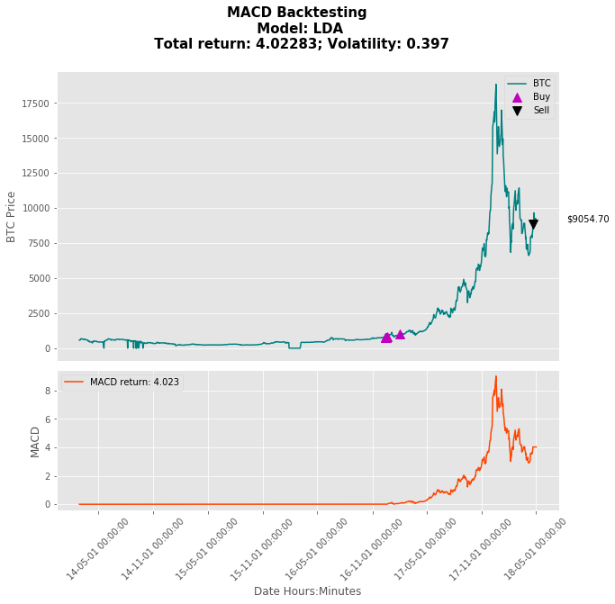

```python
backtest_macd_lda = backtest('macd', 'lda', macd.result, 10)
backtest_macd_lda.run()
```

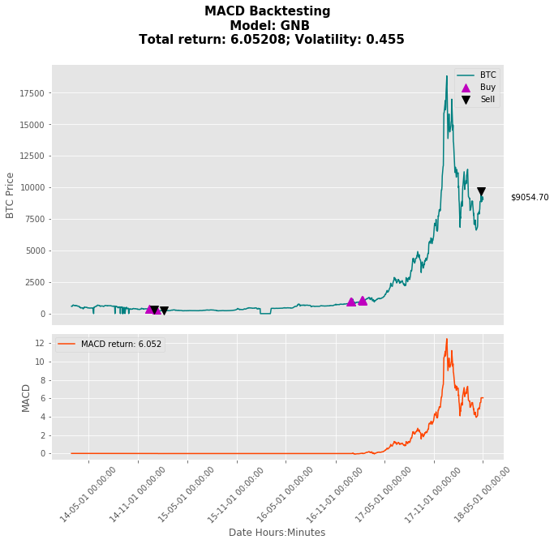

```python
backtest_macd_gnb = backtest('macd', 'gnb', macd.result, 10)
backtest_macd_gnb.run()
```

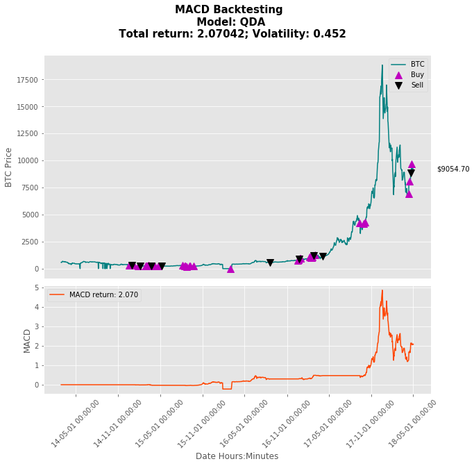

```python
backtest_macd_qda = backtest('macd', 'qda', macd.result, 10)
backtest_macd_qda.run()
```

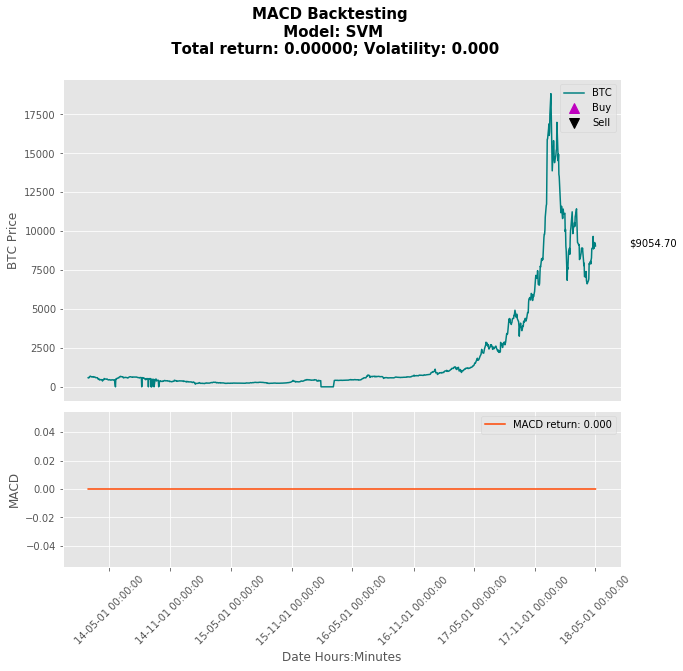

```python
backtest_macd_svm = backtest('macd', 'svm', macd.result, 10)
backtest_macd_svm.run()
```

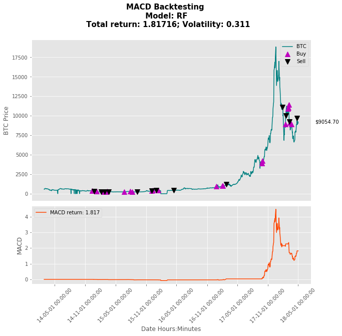

```python
backtest_macd_rf = backtest('macd', 'rf', macd.result, 10)
backtest_macd_rf.run()
```

### 4.2.2) RSI Back Testing Demo

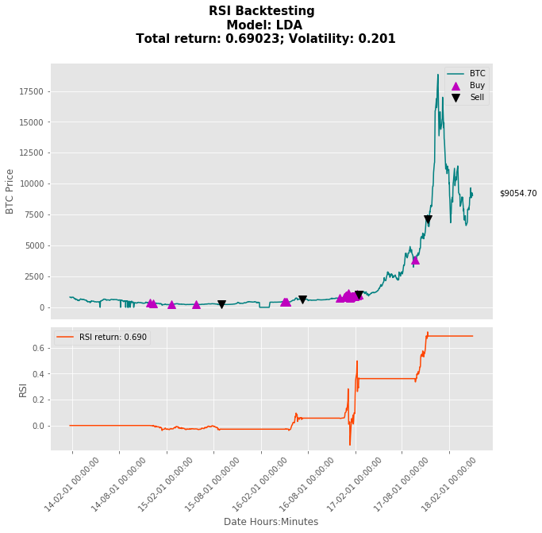

```python
backtest_rsi_lda = backtest('rsi', 'lda', rsi.result, 10)
backtest_rsi_lda.run()
```

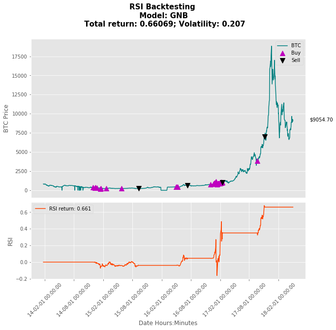

```python
backtest_rsi_gnb = backtest('rsi', 'gnb', rsi.result, 10)
backtest_rsi_gnb.run()
```

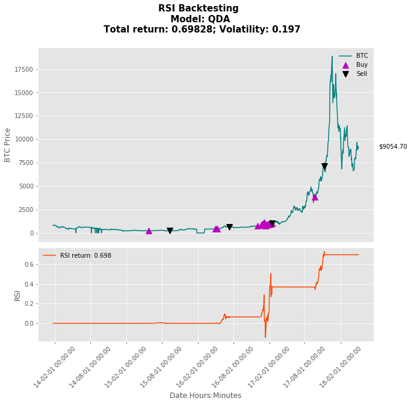

```python
backtest_rsi_qda = backtest('rsi', 'qda', rsi.result, 10)
backtest_rsi_qda.run()
```

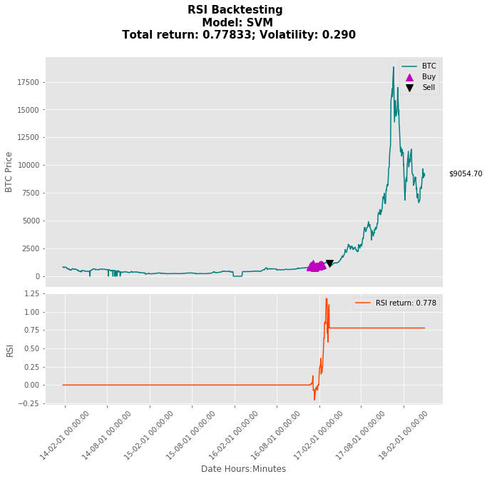

```python
backtest_rsi_svm = backtest('rsi', 'svm', rsi.result, 10)
backtest_rsi_svm.run()
```

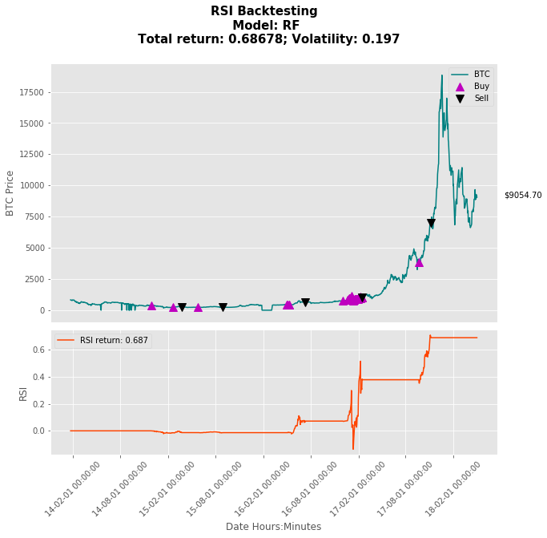

```python
backtest_rsi_rf = backtest('rsi', 'rf', rsi.result, 10)
backtest_rsi_rf.run()
```

### 4.2.3) MACD and RSI Back Testing Demo

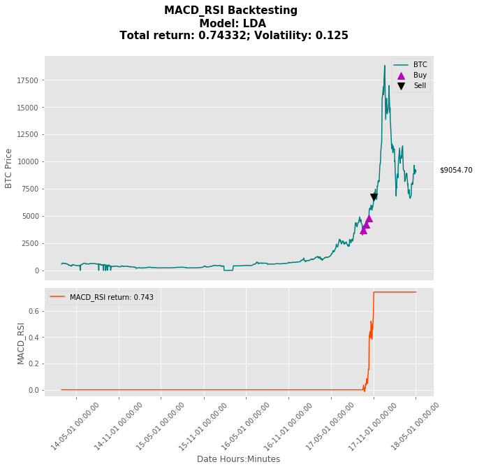

```python
backtest_macdrsi_lda = backtest('macd_rsi', 'lda', macd_rsi.result, 10, start = 600)
backtest_macdrsi_lda.run()
```

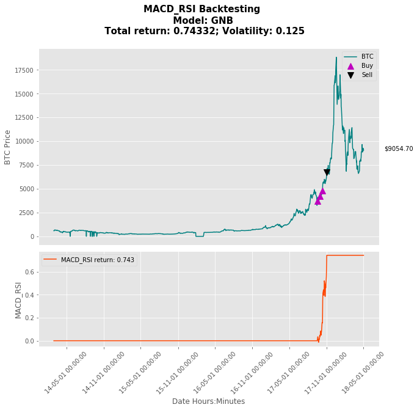

```python
backtest_macdrsi_gnb = backtest('macd_rsi', 'gnb', macd_rsi.result, 10, start = 600)
backtest_macdrsi_gnb.run()
```

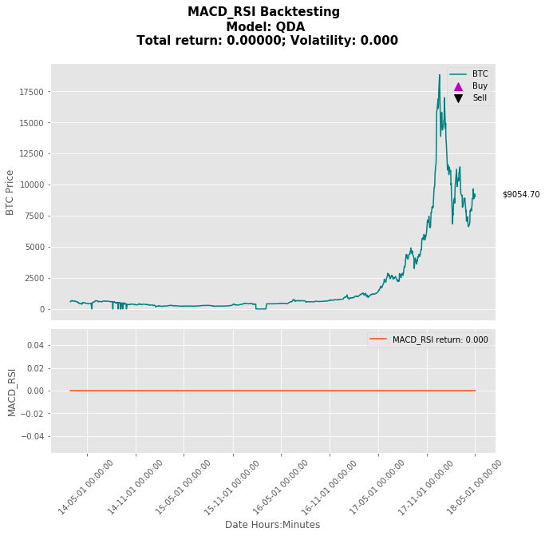

```python
backtest_macdrsi_qda = backtest('macd_rsi', 'qda', macd_rsi.result, 10, start = 600)
backtest_macdrsi_qda.run()
```

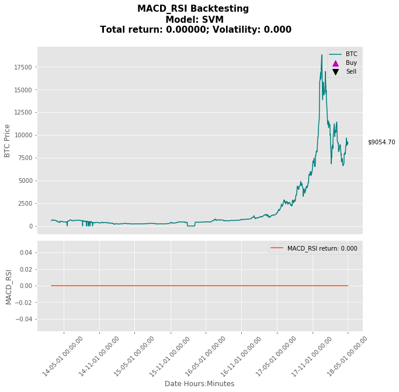

```python
backtest_macdrsi_svm = backtest('macd_rsi', 'svm', macd_rsi.result, 10, start = 600)
backtest_macdrsi_svm.run()
```

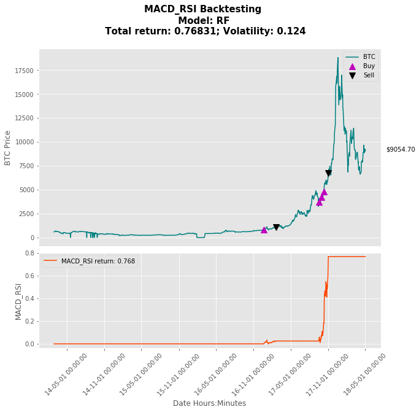

```python
backtest_macdrsi_rf = backtest('macd_rsi', 'rf', macd_rsi.result, 10, start = 600)
backtest_macdrsi_rf.run()
```